# Estate Mind – Exploratory Data Analysis

**Dataset used:** 22,844 scraped listings, 19 columns, collected between 2026-01-05 and 2026-02-24. For market analysis, a validity filter was applied: 1,000 ≤ price ≤ 5,000,000 TND and 10 ≤ surface ≤ 2,000 m², leaving **16,898** usable observations.

## 1) Market structure overview

| Metric | Value |
| --- | --- |
| Total observations | 22,844 |
| Usable observations after validity filter | 16,898 |
| Sale listings | 9,689 |
| Rental listings | 7,209 |
| Average price (usable subset) | 246,482 TND |
| Median price (usable subset) | 150,000 TND |
| Median sale price | 345,000 TND |
| Median rent | 1,800 TND |
| Correlation price vs surface | 0.33 |

**Interpretation:** The price distribution is **right-skewed**. The mean (246,482 TND) is clearly above the median (150,000 TND), which suggests the presence of high-value properties that pull the average upward. For robust analysis, the median should therefore be preferred to the mean.

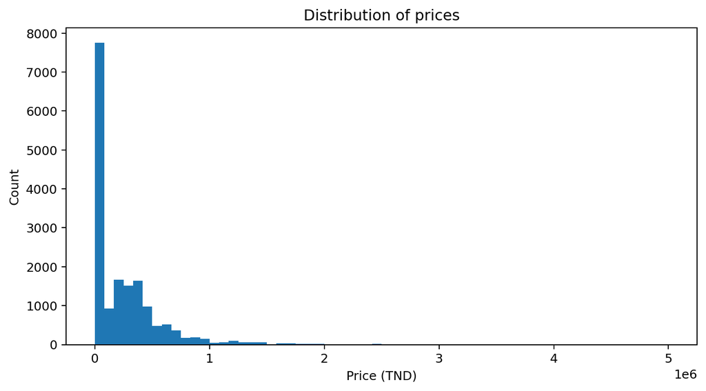

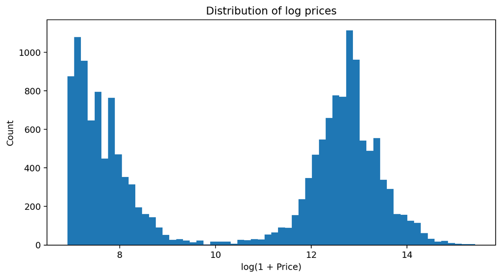

## 2) Price vs surface

The relationship between price and surface is positive but only moderate (correlation = **0.33**). This means surface matters, but it is not enough on its own: location, property type, transaction type and quality of the asset also play a major role. The wide vertical spread for similar surfaces suggests strong territorial and product heterogeneity.

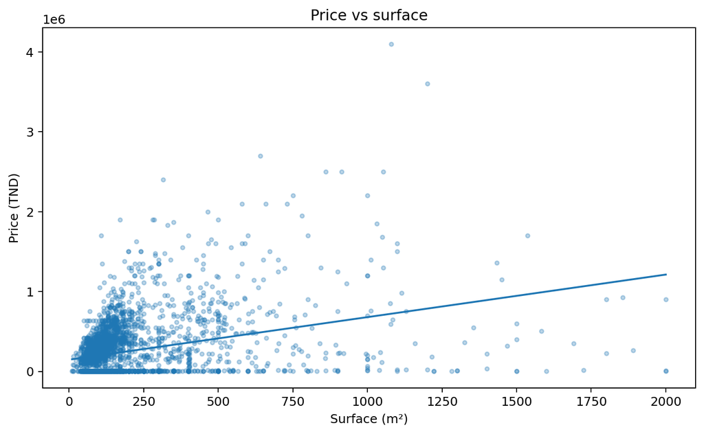

## 3) Territorial analysis

To avoid mixing sales and rentals, the territorial comparison below uses **sale listings only**. This makes the comparison more meaningful for valuation.

- **Le Kram**: median sale price = 635,000 TND (n=421)
- **La Marsa**: median sale price = 420,000 TND (n=899)
- **La Soukra**: median sale price = 399,500 TND (n=594)
- **Sahloul**: median sale price = 370,000 TND (n=105)
- **Akouda**: median sale price = 366,000 TND (n=111)
- **Khezama Est**: median sale price = 365,000 TND (n=65)

These differences support BO2 (territorial intelligence) and BO3 (valuation): the market is not homogeneous, and any pricing model should explicitly incorporate geographic variables.

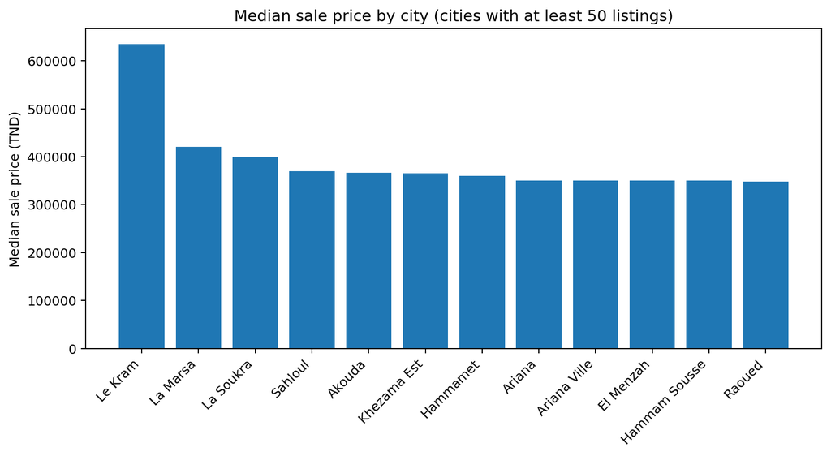

## 4) Property structure

The raw `property_type` field is not yet harmonized across sources, so a first **heuristic extraction** was used from titles and descriptions. This is enough for EDA, but a full canonical taxonomy will still be needed before modeling.

- **appartement**: 11,968
- **terrain**: 1,893
- **villa**: 1,250
- **bureau_local**: 896
- **autre**: 374
- **maison**: 368

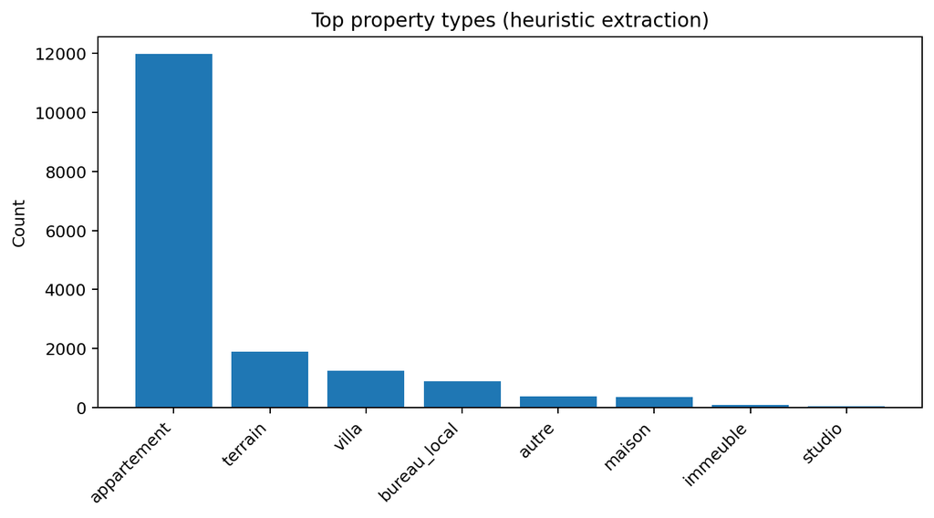

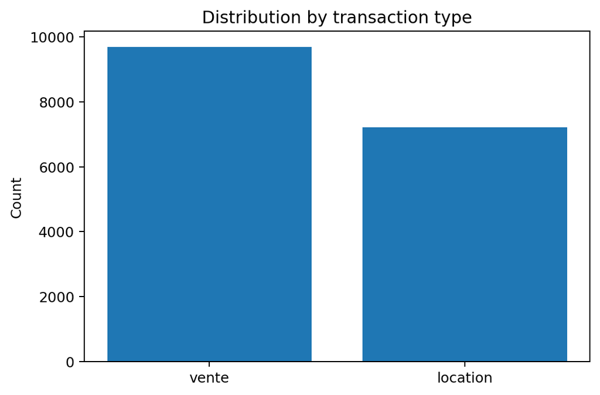

## 5) Missing values

Missingness is overall low, but not zero. The most affected field is `url` (~3.24%), followed by `description` (~0.12%). Even small gaps can matter because textual fields are important for later trust scoring and type harmonization.

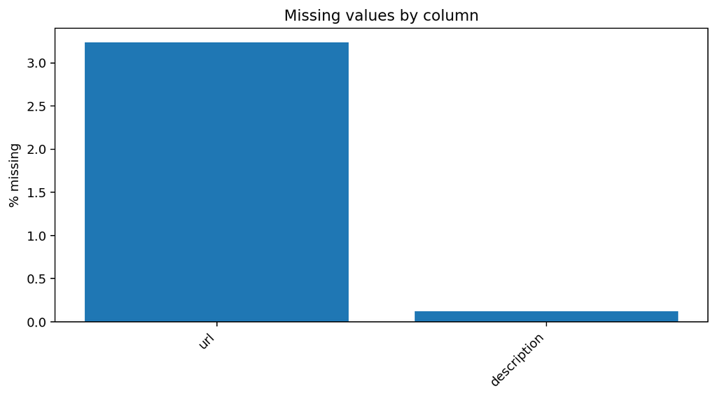

## 6) Outliers and data quality flags

- **price <= 0**: 1,044
- **price < 1000**: 4,589
- **price > 5,000,000**: 93
- **surface <= 0**: 345
- **surface < 10**: 1,292
- **surface > 2000**: 408
- **bedrooms > 20**: 67
- **bathrooms > 20**: 27
- **duplicate url**: 739
- **duplicate (source, listing_id)**: 0

These anomalies justify BO1 (market reliability) and confirm the need for cleaning rules, anomaly detection, and trust scoring. In particular, prices below 1,000 TND, surfaces below 10 m², and extreme bedroom/bathroom values should not be fed directly into predictive models.

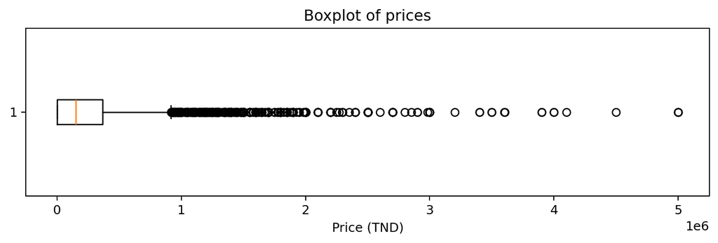

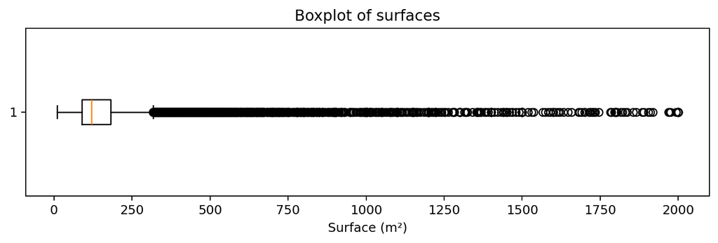

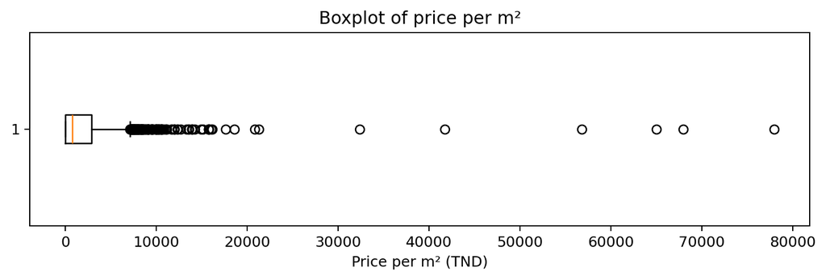

## 7) Key insights linked to BO / DSO

- **BO1 – Market reliability:** duplicates, invalid prices and extreme values show that trust and anomaly detection are necessary.
- **BO2 – Territorial dynamics:** strong city-level price differences justify territorial intelligence and spatial aggregation.
- **BO3 – Valuation:** price and surface are related, but not enough; location and transaction type must be part of the model.
- **BO5 – Legal / compliance:** the lack of harmonized semantics in some fields suggests that regulatory and textual enrichment will be useful before advanced reasoning.

## 8) Data source description and preparation rationale

The dataset aggregates cleaned listings collected from multiple Tunisian real-estate platforms. Each source contributes complementary value: some provide strong market coverage and freshness, while others provide more structured or agency-curated content. This multi-source strategy is necessary because the Tunisian market is fragmented and no single source is sufficient to represent it faithfully.

Before analysis, a first validity filter was applied to remove clearly implausible records. In particular, listings with prices below 1,000 TND or above 5,000,000 TND, and listings with surface below 10 m² or above 2,000 m², were excluded from the market-level EDA. This step does not claim that all excluded values are impossible, but it prevents a small number of extreme records from distorting the first interpretation of the market.

## 9) Methodology used for exploratory data analysis

The exploratory analysis was designed to answer three questions. First, what is the global structure of the market in terms of price, transaction type and property families? Second, how do price levels vary with surface and geography? Third, what quality issues remain visible after the first cleaning phase?

For this reason, the EDA combines descriptive statistics, univariate visualizations, bivariate plots, territorial comparisons and basic quality diagnostics. The objective is not only to describe the data, but also to identify the variables and issues that matter most for later modeling.

## 10) Implications for modeling and business objectives

The EDA directly supports the business and data-science objectives defined in Phase 1. The strong asymmetry of prices and the presence of outliers justify robust valuation strategies and anomaly detection. The large territorial variation confirms that spatial information must be explicitly integrated in BO2 and BO3. The moderate relationship between price and surface suggests that pricing models cannot rely on a single feature and must combine location, transaction type and property characteristics.

In addition, the remaining issues in semantics and field harmonization confirm the importance of BO1. Reliable market intelligence requires not only more data, but also cleaner and more standardized data. The current EDA therefore plays a double role: it improves understanding of the Tunisian market and it guides the next preparation steps before predictive modeling.

## 11) Conclusion of the EDA phase

This first exploratory analysis shows that the collected data already contains enough structure to reveal meaningful market patterns, but it also confirms that careful preparation remains necessary. Prices are highly skewed, territorial disparities are strong, and some variables are still heterogeneous across sources.

As a result, the next steps should focus on stronger field harmonization, duplicate management, territorial enrichment and the preparation of modeling-ready datasets. In that sense, the EDA is not an isolated exercise: it is the bridge between raw collected data and the future valuation, territorial and decision-support modules of Estate Mind.